# M4 Lab

Matthew Præstgaard

Spring 2024

# Lab Setup

## All code available on https://github.com/matthewep528/BIOSTLabs

## Note: Some results may not show up properly in the default dark theme and only in the light theme

Load necessary packages.

```r
library(tidyverse)
library(here)
library(lmtest)
library(glmtoolbox)
library(car)
library(jtools)
```

## Data management

The following data come from the SEER cancer registry. We are interested in studying early mortality (defined as death within 2 months of cancer diagnosis) and potential risk factors. Notice there are some missing values in the residency and income variables, make sure to drop the missing values from the data so each model is fit using the same data.

```r
# read in data
# I've included code to turn sex and race into factor variables for you

seer <- read_csv(here("Lab4", "seer2016.csv")) %>%
  mutate(
    race = factor(race,
      levels = c(0, 1, 2, 3, 99),
      labels = c("White", "Black", "American Indian/Alaska Native", "Asian or Pacific Islander", "Unknown")
    ),
    sex = factor(sex,
      levels = c(0, 1),
      labels = c("Male", "Female")
    ),
    mortality_f = factor(early_mortality,
      levels = c(0, 1),
      labels = c("No", "Yes")
    )
  ) %>%
  drop_na() # dropping NAs
```

# Data Analysis

## 1. Contingency table

**Make a contingency table showing the breakdown of early mortality by primary cancer site (use the grouped variable, grouped_primary).** **Make the contingency table that shows the raw counts and a second that shows the proportion of early mortality vs not early mortality within each primary cancer site.**

```r
# table of counts
tableCount <- table(seer$mortality_f, seer$grouped_primary)
kable(tableCount, caption = "Table of Counts of Early Mortality by Cancer Site")
```

Table of Counts of Early Mortality by Cancer Site

|  | Bladder | Breast | CRC | Gastro-esophageal | HCC | Head and Neck | Kidney | Lung | Melanoma | Other | Ovary | Pancreato-biliary | Prostate |
| --- | --- | --- | --- | --- | --- | --- | --- | --- | --- | --- | --- | --- | --- |
| No | 45 | 290 | 372 | 231 | 32 | 104 | 129 | 1266 | 51 | 227 | 124 | 366 | 291 |
| Yes | 9 | 19 | 61 | 59 | 18 | 4 | 17 | 405 | 11 | 37 | 17 | 152 | 10 |

```r
# table of proportions by cancer site
tableProp <- prop.table(tableCount, 1)
kable(tableProp, caption = "Table of Proportions of Early Mortality by Cancer Site")
```

Table of Proportions of Early Mortality by Cancer Site

|  | Bladder | Breast | CRC | Gastro-esophageal | HCC | Head and Neck | Kidney | Lung | Melanoma | Other | Ovary | Pancreato-biliary | Prostate |
| --- | --- | --- | --- | --- | --- | --- | --- | --- | --- | --- | --- | --- | --- |
| No | 0.0127551 | 0.0821995 | 0.1054422 | 0.0654762 | 0.0090703 | 0.0294785 | 0.0365646 | 0.3588435 | 0.0144558 | 0.0643424 | 0.0351474 | 0.1037415 | 0.082483 |
| Yes | 0.0109890 | 0.0231990 | 0.0744811 | 0.0720391 | 0.0219780 | 0.0048840 | 0.0207570 | 0.4945055 | 0.0134310 | 0.0451770 | 0.0207570 | 0.1855922 | 0.012210 |

## 2. Odds and odds ratios (table based)

**Using this table calculate the odds of early mortality for people with bladder cancer, the odds of early mortality for people with breast cancer,** **and the odds ratio for early mortality comparing breast cancer to bladder cancer.** **Which group has the higher odds of early mortality, people with primary breast cancer or bladder cancer?**

### odds for bladder cancer:

$$\displaystyle{\displaylines{Odds_{Bladder}=9/45=0.2}}$$

### odds for breast cancer:

$$\displaystyle{\displaylines{Odds_{Breast}=19/290=0.066}}$$

### odds ratio:

$$\displaystyle{\displaylines{OR =
0.066/0.2 = \textbf{0.326}}}$$

## 3. Logistic regression model (single predictor)

**Fit a logistic regression model using just primary cancer site (grouped_primary) as the sole predictor. Show the model output. Interpret the intercept and first coefficient (coefficient for breast cancer) in this model.**

```r
# recall to fit a logistic regression model we use glm(y ~ x1 + x2 + ..., data = data_name, family = binomial(link="logit"))
# fit logistic regression model
glmSite <- glm(early_mortality ~ grouped_primary, data = seer, family = binomial(link = "logit"))
# summary(glmSite)
# print output
summ(glmSite)
```

| Observations | 4347 |
| --- | --- |
| Dependent variable | early_mortality |
| Type | Generalized linear model |
| Family | binomial |
| Link | logit |

| χ²(12) | 224.69 |
| --- | --- |
| Pseudo-R² (Cragg-Uhler) | 0.08 |
| Pseudo-R² (McFadden) | 0.05 |
| AIC | 4008.37 |
| BIC | 4091.27 |

|  | Est. | S.E. | z val. | p |
| --- | --- | --- | --- | --- |
| (Intercept) | -1.61 | 0.37 | -4.41 | 0.00 |
| grouped_primaryBreast | -1.12 | 0.44 | -2.56 | 0.01 |
| grouped_primaryCRC | -0.20 | 0.39 | -0.51 | 0.61 |
| grouped_primaryGastro-esophageal | 0.24 | 0.39 | 0.62 | 0.53 |
| grouped_primaryHCC | 1.03 | 0.47 | 2.20 | 0.03 |
| grouped_primaryHead and Neck | -1.65 | 0.63 | -2.63 | 0.01 |
| grouped_primaryKidney | -0.42 | 0.45 | -0.93 | 0.35 |
| grouped_primaryLung | 0.47 | 0.37 | 1.27 | 0.20 |
| grouped_primaryMelanoma | 0.08 | 0.49 | 0.15 | 0.88 |
| grouped_primaryOther | -0.20 | 0.41 | -0.50 | 0.61 |
| grouped_primaryOvary | -0.38 | 0.45 | -0.84 | 0.40 |
| grouped_primaryPancreato-biliary | 0.73 | 0.38 | 1.93 | 0.05 |
| grouped_primaryProstate | -1.76 | 0.49 | -3.62 | 0.00 |

Standard errors: MLE

### Interpretation

Intercept: the intercept of **-1.61** represents the log odds of the event with all predictors at 0. In the model, the reference is bladder cancer.

Coefficient for breast cancer: The coefficient for breast cancer of **-1.12** represents the log odds ratio of early mortality for breast cancer compared to the reference category.

## 4. Odds and odds ratios (model based)

**Based on the model you fit above, estimate the odds of early mortality for people with bladder cancer, for people with breast cancer,** **and the odds ratio for early mortality comparing breast cancer to bladder cancer. How do these compare to the answers you got in part 2?**

**calculations were done manually since I think LaTeX looks cool**

Odds for breast cancer:
$$\displaystyle{\displaylines{Odds_{breast} =
e^{-1.61+-1.12} = 0.065}}$$

Odds for bladder cancer:
$$\displaystyle{\displaylines{Odds_{breast} =
e^{-1.61} = 0.2}}$$

Odds ratio:
$$OR_{\text{Breast vs
Reference}} = \frac{Odds_{\text{Breast}}}{Odds_{\text{Reference}}} =
e^{-1.12} \approx 0.326$$

These results are in line with the results from part 2.

## 5. Logistic regression model (multiple predictors)

**Now, in addition to primary cancer site, add sex, race, age, residency category, and income category to the model. Show the model output.**

```r
# fit model
glmMulti <- glm(early_mortality ~ grouped_primary + sex + race + age + cat_res + income_cat, data = seer, family = binomial(link = "logit"))

# print model output
summ(glmMulti)
```

| Observations | 4347 |
| --- | --- |
| Dependent variable | early_mortality |
| Type | Generalized linear model |
| Family | binomial |
| Link | logit |

| χ²(21) | 330.73 |
| --- | --- |
| Pseudo-R² (Cragg-Uhler) | 0.12 |
| Pseudo-R² (McFadden) | 0.08 |
| AIC | 3920.32 |
| BIC | 4060.62 |

|  | Est. | S.E. | z val. | p |
| --- | --- | --- | --- | --- |
| (Intercept) | -3.78 | 0.44 | -8.63 | 0.00 |
| grouped_primaryBreast | -0.80 | 0.44 | -1.80 | 0.07 |
| grouped_primaryCRC | -0.01 | 0.40 | -0.03 | 0.98 |
| grouped_primaryGastro-esophageal | 0.43 | 0.40 | 1.08 | 0.28 |
| grouped_primaryHCC | 1.21 | 0.48 | 2.54 | 0.01 |
| grouped_primaryHead and Neck | -1.47 | 0.63 | -2.34 | 0.02 |
| grouped_primaryKidney | -0.22 | 0.45 | -0.49 | 0.63 |
| grouped_primaryLung | 0.57 | 0.37 | 1.52 | 0.13 |
| grouped_primaryMelanoma | 0.33 | 0.50 | 0.66 | 0.51 |
| grouped_primaryOther | 0.13 | 0.41 | 0.32 | 0.75 |
| grouped_primaryOvary | -0.15 | 0.46 | -0.33 | 0.74 |
| grouped_primaryPancreato-biliary | 0.89 | 0.38 | 2.34 | 0.02 |
| grouped_primaryProstate | -1.85 | 0.49 | -3.76 | 0.00 |
| sexFemale | -0.20 | 0.09 | -2.29 | 0.02 |
| raceBlack | 0.06 | 0.12 | 0.52 | 0.60 |
| raceAmerican Indian/Alaska Native | 0.14 | 0.46 | 0.31 | 0.76 |
| raceAsian or Pacific Islander | -0.14 | 0.16 | -0.86 | 0.39 |
| raceUnknown | 0.15 | 0.61 | 0.25 | 0.80 |
| age | 0.03 | 0.00 | 9.46 | 0.00 |
| cat_resRural | 0.11 | 0.20 | 0.57 | 0.57 |
| cat_resUrban | -0.00 | 0.09 | -0.01 | 1.00 |
| income_catBelow 65K | 0.29 | 0.09 | 3.31 | 0.00 |

Standard errors: MLE

```r
summary(glmMulti)
```

```
##
## Call:
## glm(formula = early_mortality ~ grouped_primary + sex + race +
##     age + cat_res + income_cat, family = binomial(link = "logit"),
##     data = seer)
##
## Coefficients:
##                                     Estimate Std. Error z value Pr(>|z|)
## (Intercept)                       -3.7814261  0.4379817  -8.634  < 2e-16 ***
## grouped_primaryBreast             -0.7973994  0.4434895  -1.798 0.072175 .
## grouped_primaryCRC                -0.0101702  0.3955682  -0.026 0.979488
## grouped_primaryGastro-esophageal   0.4327646  0.3988896   1.085 0.277956
## grouped_primaryHCC                 1.2098206  0.4757884   2.543 0.010998 *
## grouped_primaryHead and Neck      -1.4748772  0.6314782  -2.336 0.019512 *
## grouped_primaryKidney             -0.2208500  0.4528465  -0.488 0.625767
## grouped_primaryLung                0.5689150  0.3742895   1.520 0.128514
## grouped_primaryMelanoma            0.3314445  0.5019698   0.660 0.509069
## grouped_primaryOther               0.1319025  0.4129427   0.319 0.749407
## grouped_primaryOvary              -0.1486852  0.4561299  -0.326 0.744446
## grouped_primaryPancreato-biliary   0.8948446  0.3829212   2.337 0.019445 *
## grouped_primaryProstate           -1.8485896  0.4918612  -3.758 0.000171 ***
## sexFemale                         -0.1966828  0.0858772  -2.290 0.022005 *
## raceBlack                          0.0640932  0.1222530   0.524 0.600093
## raceAmerican Indian/Alaska Native  0.1410459  0.4577404   0.308 0.757979
## raceAsian or Pacific Islander     -0.1359981  0.1580868  -0.860 0.389637
## raceUnknown                        0.1520414  0.6051627   0.251 0.801628
## age                                0.0285330  0.0030146   9.465  < 2e-16 ***
## cat_resRural                       0.1131781  0.1968538   0.575 0.565335
## cat_resUrban                      -0.0004442  0.0885952  -0.005 0.995999
## income_catBelow 65K                0.2879207  0.0870399   3.308 0.000940 ***
## ---
## Signif. codes:  0 '***' 0.001 '**' 0.01 '*' 0.05 '.' 0.1 ' ' 1
##
## (Dispersion parameter for binomial family taken to be 1)
##
##     Null deviance: 4207.1  on 4346  degrees of freedom
## Residual deviance: 3876.3  on 4325  degrees of freedom
## AIC: 3920.3
##
## Number of Fisher Scoring iterations: 6
```

## 6. Interpret coefficients

**Intercept:** The intercept of **-3.78** represents the log odds of early mortality for the reference category of each variable when all other predictors are held at their reference level.

**Coefficient for breast cancer:** The coefficient for breast cancer of **-0.797** represents the log odds ratio ratio of early mortality for patients with breast cancer compared to the reference cancer type, holding all other variables constant.

## 7. Predicted value

```r
# the seer dataset as it is was giving me trouble, so I made this one with the cat_res and income_cat columns explictly defined as factors
seer2 <- seer %>%
  mutate(
    cat_res = as.factor(cat_res),
    income_cat = as.factor(income_cat)
  )
# calculate predicted probability (note: this is different from the odds)
new_individual <- data.frame(
  grouped_primary = factor("Lung"),
  sex = factor("Male"),
  race = factor("Black"),
  age = 60,
  cat_res = factor("Urban"),
  income_cat = factor("Below 65K")
)

predict(glmMulti, newdata = new_individual, type = "response")
```

```
##         1
## 0.2406788
```

## 8. Confidence intervals

**Construct 95% confidence intervals on the log-odds scale and on the odds scale for all coefficients in the model (from part 5).**

*Note: the code here might take a few seconds to run*

```r
# log scale
confint_log_odds <- confint(glmMulti, level = 0.95)
kable(confint_log_odds)
```

|  | 2.5 % | 97.5 % |
| --- | --- | --- |
| (Intercept) | -4.6894726 | -2.9596713 |
| grouped_primaryBreast | -1.6450922 | 0.1114455 |
| grouped_primaryCRC | -0.7451995 | 0.8219880 |
| grouped_primaryGastro-esophageal | -0.3094090 | 1.2705880 |
| grouped_primaryHCC | 0.2981500 | 2.1786003 |
| grouped_primaryHead and Neck | -2.8296032 | -0.2894486 |
| grouped_primaryKidney | -1.0902744 | 0.7033365 |
| grouped_primaryLung | -0.1180721 | 1.3662521 |
| grouped_primaryMelanoma | -0.6524430 | 1.3365004 |
| grouped_primaryOther | -0.6426352 | 0.9924880 |
| grouped_primaryOvary | -1.0248761 | 0.7812811 |
| grouped_primaryPancreato-biliary | 0.1887022 | 1.7064684 |
| grouped_primaryProstate | -2.8200523 | -0.8665352 |
| sexFemale | -0.3653900 | -0.0286683 |
| raceBlack | -0.1790703 | 0.3005601 |
| raceAmerican Indian/Alaska Native | -0.8269975 | 0.9934078 |
| raceAsian or Pacific Islander | -0.4538570 | 0.1668754 |
| raceUnknown | -1.1682323 | 1.2613569 |
| age | 0.0226414 | 0.0344620 |
| cat_resRural | -0.2823563 | 0.4909943 |
| cat_resUrban | -0.1748162 | 0.1725743 |
| income_catBelow 65K | 0.1177283 | 0.4590134 |

```r
# odds scale
confint_odds <- confint_log_odds %>% exp()
kable(confint_odds)
```

|  | 2.5 % | 97.5 % |
| --- | --- | --- |
| (Intercept) | 0.0091915 | 0.0518360 |
| grouped_primaryBreast | 0.1929948 | 1.1178928 |
| grouped_primaryCRC | 0.4746396 | 2.2750182 |
| grouped_primaryGastro-esophageal | 0.7338805 | 3.5629471 |
| grouped_primaryHCC | 1.3473639 | 8.8339330 |
| grouped_primaryHead and Neck | 0.0590363 | 0.7486763 |
| grouped_primaryKidney | 0.3361242 | 2.0204828 |
| grouped_primaryLung | 0.8886320 | 3.9206290 |
| grouped_primaryMelanoma | 0.5207720 | 3.8057017 |
| grouped_primaryOther | 0.5259047 | 2.6979387 |
| grouped_primaryOvary | 0.3588409 | 2.1842688 |
| grouped_primaryPancreato-biliary | 1.2076813 | 5.5094698 |
| grouped_primaryProstate | 0.0596028 | 0.4204057 |
| sexFemale | 0.6939260 | 0.9717387 |
| raceBlack | 0.8360471 | 1.3506151 |
| raceAmerican Indian/Alaska Native | 0.4373605 | 2.7004213 |
| raceAsian or Pacific Islander | 0.6351736 | 1.1816070 |
| raceUnknown | 0.3109161 | 3.5302084 |
| age | 1.0228996 | 1.0350627 |
| cat_resRural | 0.7540050 | 1.6339400 |
| cat_resUrban | 0.8396113 | 1.1883601 |
| income_catBelow 65K | 1.1249384 | 1.5825119 |

## 9. Interactions

**Add an interaction between sex and income category. Interpret the coefficient for this term in the model. What does it mean if it is positive?**

```r
# fit model with interaction
glmInt <- glm(early_mortality ~ grouped_primary + sex + race + age + cat_res + income_cat + sex:income_cat, data = seer, family = binomial(link = "logit"))

summ(glmInt)
```

| Observations | 4347 |
| --- | --- |
| Dependent variable | early_mortality |
| Type | Generalized linear model |
| Family | binomial |
| Link | logit |

| χ²(22) | 331.26 |
| --- | --- |
| Pseudo-R² (Cragg-Uhler) | 0.12 |
| Pseudo-R² (McFadden) | 0.08 |
| AIC | 3921.79 |
| BIC | 4068.47 |

|  | Est. | S.E. | z val. | p |
| --- | --- | --- | --- | --- |
| (Intercept) | -3.75 | 0.44 | -8.54 | 0.00 |
| grouped_primaryBreast | -0.80 | 0.44 | -1.80 | 0.07 |
| grouped_primaryCRC | -0.01 | 0.40 | -0.02 | 0.98 |
| grouped_primaryGastro-esophageal | 0.43 | 0.40 | 1.08 | 0.28 |
| grouped_primaryHCC | 1.21 | 0.48 | 2.54 | 0.01 |
| grouped_primaryHead and Neck | -1.48 | 0.63 | -2.34 | 0.02 |
| grouped_primaryKidney | -0.22 | 0.45 | -0.48 | 0.63 |
| grouped_primaryLung | 0.57 | 0.37 | 1.52 | 0.13 |
| grouped_primaryMelanoma | 0.33 | 0.50 | 0.65 | 0.51 |
| grouped_primaryOther | 0.13 | 0.41 | 0.31 | 0.75 |
| grouped_primaryOvary | -0.15 | 0.46 | -0.34 | 0.74 |
| grouped_primaryPancreato-biliary | 0.89 | 0.38 | 2.34 | 0.02 |
| grouped_primaryProstate | -1.85 | 0.49 | -3.76 | 0.00 |
| sexFemale | -0.27 | 0.13 | -2.07 | 0.04 |
| raceBlack | 0.07 | 0.12 | 0.53 | 0.59 |
| raceAmerican Indian/Alaska Native | 0.15 | 0.46 | 0.32 | 0.75 |
| raceAsian or Pacific Islander | -0.13 | 0.16 | -0.85 | 0.39 |
| raceUnknown | 0.14 | 0.61 | 0.24 | 0.81 |
| age | 0.03 | 0.00 | 9.49 | 0.00 |
| cat_resRural | 0.11 | 0.20 | 0.58 | 0.56 |
| cat_resUrban | 0.00 | 0.09 | 0.01 | 0.99 |
| income_catBelow 65K | 0.23 | 0.12 | 1.98 | 0.05 |
| sexFemale:income_catBelow 65K | 0.12 | 0.16 | 0.73 | 0.47 |

Standard errors: MLE

```r
summary(glmInt)
```

```
##
## Call:
## glm(formula = early_mortality ~ grouped_primary + sex + race +
##     age + cat_res + income_cat + sex:income_cat, family = binomial(link = "logit"),
##     data = seer)
##
## Coefficients:
##                                     Estimate Std. Error z value Pr(>|z|)
## (Intercept)                       -3.7535036  0.4395644  -8.539  < 2e-16 ***
## grouped_primaryBreast             -0.7977058  0.4435640  -1.798  0.07211 .
## grouped_primaryCRC                -0.0092945  0.3956394  -0.023  0.98126
## grouped_primaryGastro-esophageal   0.4294367  0.3989848   1.076  0.28178
## grouped_primaryHCC                 1.2087584  0.4757894   2.541  0.01107 *
## grouped_primaryHead and Neck      -1.4751951  0.6314883  -2.336  0.01949 *
## grouped_primaryKidney             -0.2173111  0.4529029  -0.480  0.63136
## grouped_primaryLung                0.5690956  0.3743598   1.520  0.12846
## grouped_primaryMelanoma            0.3279604  0.5019680   0.653  0.51353
## grouped_primaryOther               0.1295786  0.4130313   0.314  0.75373
## grouped_primaryOvary              -0.1537206  0.4563549  -0.337  0.73623
## grouped_primaryPancreato-biliary   0.8946439  0.3829881   2.336  0.01949 *
## grouped_primaryProstate           -1.8496605  0.4919001  -3.760  0.00017 ***
## sexFemale                         -0.2666371  0.1291131  -2.065  0.03891 *
## raceBlack                          0.0650032  0.1222541   0.532  0.59493
## raceAmerican Indian/Alaska Native  0.1477362  0.4575425   0.323  0.74678
## raceAsian or Pacific Islander     -0.1347288  0.1581141  -0.852  0.39416
## raceUnknown                        0.1422528  0.6051042   0.235  0.81414
## age                                0.0286175  0.0030171   9.485  < 2e-16 ***
## cat_resRural                       0.1147570  0.1968241   0.583  0.55986
## cat_resUrban                       0.0006924  0.0886018   0.008  0.99376
## income_catBelow 65K                0.2310131  0.1169169   1.976  0.04817 *
## sexFemale:income_catBelow 65K      0.1193550  0.1643569   0.726  0.46772
## ---
## Signif. codes:  0 '***' 0.001 '**' 0.01 '*' 0.05 '.' 0.1 ' ' 1
##
## (Dispersion parameter for binomial family taken to be 1)
##
##     Null deviance: 4207.1  on 4346  degrees of freedom
## Residual deviance: 3875.8  on 4324  degrees of freedom
## AIC: 3921.8
##
## Number of Fisher Scoring iterations: 6
```

**Interpretation:** The coefficient for the interaction term between sex and income category measures how the relationship between sex and the probability of early mortality changes across different levels of income category

A positive coefficient suggests that the effect of being in the lower income category on the odds of early mortality is greater for females compared to males.

## 10. Hypothesis Tests

**Test for effect modification of income by sex (the interaction specified above) using both the Wald test statistic and likelihood ratio test. Interpret your results.**

```r
# likelihood ratio test
lrtest(glmMulti, glmInt)
```

```
## Likelihood ratio test
##
## Model 1: early_mortality ~ grouped_primary + sex + race + age + cat_res +
##     income_cat
## Model 2: early_mortality ~ grouped_primary + sex + race + age + cat_res +
##     income_cat + sex:income_cat
##   #Df  LogLik Df  Chisq Pr(>Chisq)
## 1  22 -1938.2
## 2  23 -1937.9  1 0.5275     0.4677
```

```r
# wald test
waldtest(glmMulti, glmInt, test = "Chisq")
```

```
## Wald test
##
## Model 1: early_mortality ~ grouped_primary + sex + race + age + cat_res +
##     income_cat
## Model 2: early_mortality ~ grouped_primary + sex + race + age + cat_res +
##     income_cat + sex:income_cat
##   Res.Df Df  Chisq Pr(>Chisq)
## 1   4325
## 2   4324  1 0.5274     0.4677
```

**Interpretation:**

Wald Test: **p = 0.47** LR Test: **p = 0.47**

The p-values for both the Wald Test and the LR Test are both above the significance threshold of p<0.05 and are nearly identical.  
These results indicate that there is likely not effect modification present.

## 11. Comparing Model Fit Metrics

**Compare the deviance-based adjusted R-squared, deviance, AIC, and BIC values for each of the three models we have fit so far (only primary cancer site, all main effects, and all main effects plus interaction). Which model seems to perform the best based on these metrics? Use the model you think is best for the remainder of the lab.**

```r
# metrics of model fit

# Extract AIC and BIC values
aic_values <- c(AIC(glmSite), AIC(glmMulti), AIC(glmInt))
bic_values <- c(BIC(glmSite), BIC(glmMulti), BIC(glmInt))

# Extract Deviance
deviance_values <- c(deviance(glmSite), deviance(glmMulti), deviance(glmInt))
null_deviance_values <- c(glmSite$null.deviance, glmMulti$null.deviance, glmInt$null.deviance)
n <- c(length(glmSite$fitted.values), length(glmMulti$fitted.values), length(glmInt$fitted.values))
adj_r_squared_values <- 1 - (deviance_values / null_deviance_values) * ((n - 1) / (n - c(length(coef(glmSite)), length(coef(glmMulti)), length(coef(glmInt))) - 1))

# Combine metrics into a data frame for comparison
comparison_df <- data.frame(
  Model = c("Only Primary Cancer Site", "All Main Effects", "All Main Effects + Interaction"),
  AIC = aic_values,
  BIC = bic_values,
  Deviance = deviance_values,
  Adjusted_R_Squared = adj_r_squared_values
)

kable(comparison_df)
```

| Model | AIC | BIC | Deviance | Adjusted_R_Squared |
| --- | --- | --- | --- | --- |
| Only Primary Cancer Site | 4008.367 | 4091.271 | 3982.367 | 0.0505671 |
| All Main Effects | 3920.322 | 4060.621 | 3876.322 | 0.0739256 |
| All Main Effects + Interaction | 3921.794 | 4068.471 | 3875.794 | 0.0738375 |

## 12. Collinearity

**Check for collinearity in the model. Do you think collinearity is an issue in the model you chose?**

```r
# check for collinearity
vif(glmMulti) %>% kable()
```

|  | GVIF | Df | GVIF^(1/(2*Df)) |
| --- | --- | --- | --- |
| grouped_primary | 1.178997 | 12 | 1.006885 |
| sex | 1.133784 | 1 | 1.064793 |
| race | 1.056921 | 4 | 1.006944 |
| age | 1.037430 | 1 | 1.018543 |
| cat_res | 1.115231 | 2 | 1.027641 |
| income_cat | 1.132653 | 1 | 1.064262 |

**Interpretation:** All VIF values are low, indicating low risk of collinearity.

## 13. Linearity

**Do you think non-linearity could be an issue in the model you chose? Assess this visually and interpret what you see.**

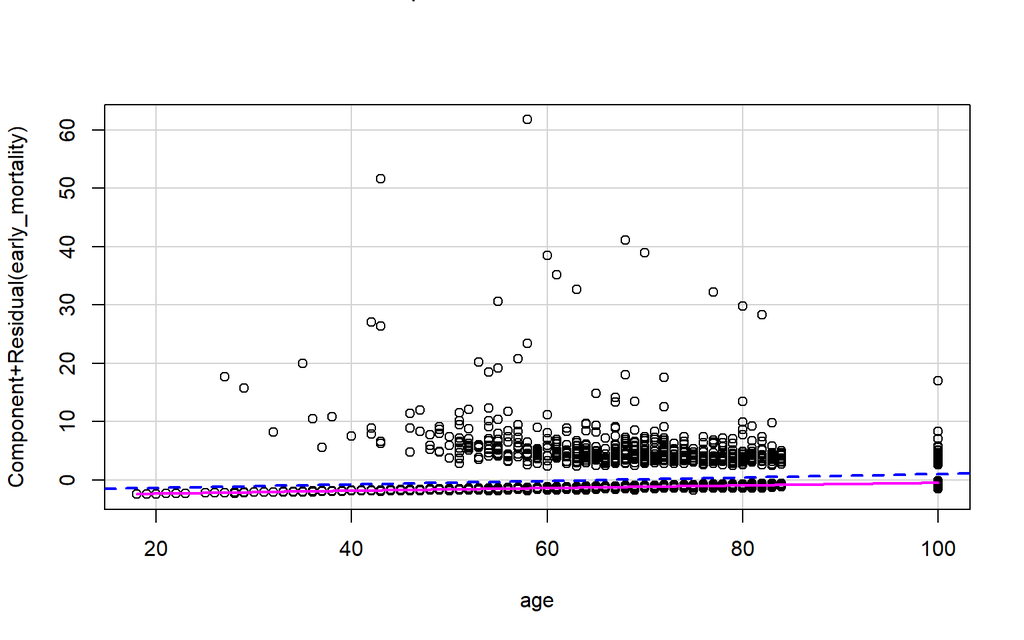

```r
# check for nonlinearity (hint: you don't need to do this for categorical variables)
# making plot using age as it is the only continuous variable used in the model
crPlots(glmMulti, terms = ~age)
```

**Interpretation:** The CR plot indicates that there is little evidence of non-linearity.

## 14. Leverage and influential points

**Assess if there are any high leverage or influential points in the model.**

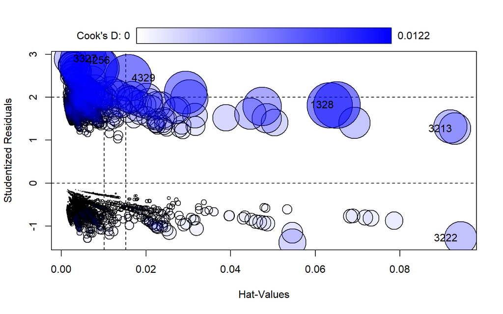

```
##        StudRes         Hat       CookD
## 1328  1.819385 0.065135263 0.012244043
## 3213  1.268941 0.093030306 0.005720686
## 3222 -1.275127 0.094390246 0.005891136
## 3327  2.895008 0.002066725 0.005755527
## 4256  2.860525 0.005189233 0.012232487
## 4329  2.446395 0.015859232 0.012249810
```

```r
# check metrics of leverage and influence
# hatvalues(glmMulti)

# using both since I thought there was a distinct lack of pretty graph opportunities in this one
influencePlot(glmMulti)
```

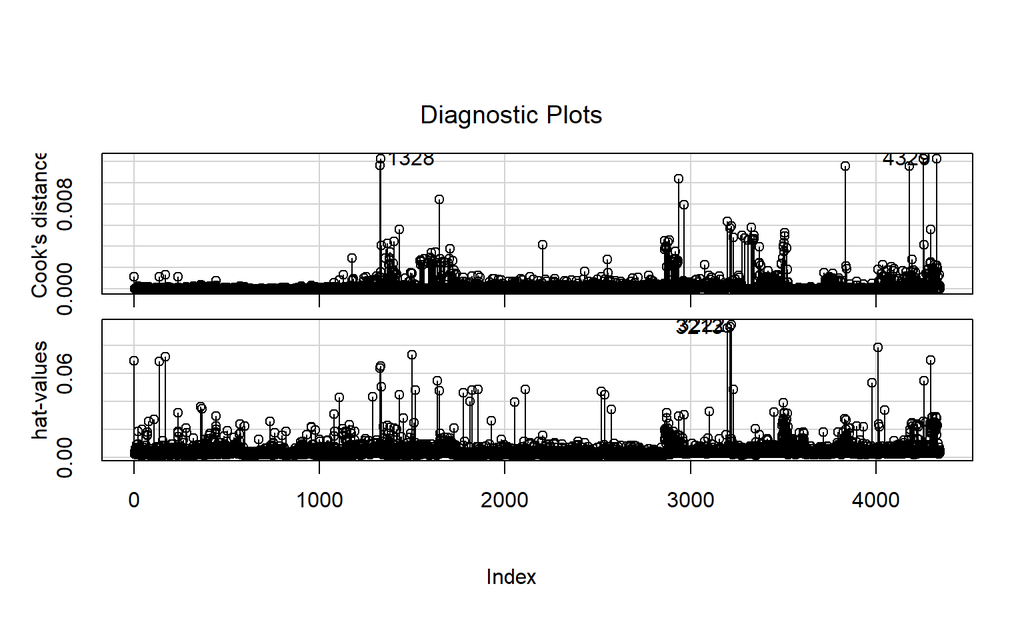

```r
influenceIndexPlot(glmMulti, c("Cook", "hat"))
```

**Interpretation:** There appear to be a few points in the model that are very influential based on the Cook’s Distance plot, but, overall, there do not seem to be many influential points. The same appears true for high leverage points based on the HAT values plot.

## 15. Hosmer-Lemeshow

**Test if the model appears to fit well to the data. Interpret your results.**

```r
# test for goodness of fit
hltest(glmMulti)
```

```
##
##    The Hosmer-Lemeshow goodness-of-fit test
##
##  Group Size Observed  Expected
##      1  436       15  13.14863
##      2  435       23  28.67641
##      3  435       42  46.84522
##      4  435       63  61.99510
##      5  437       71  75.43288
##      6  435       90  87.44906
##      7  435      106  99.28536
##      8  437      122 112.32650
##      9  435      136 129.29685
##     10  427      151 164.54400
##
##          Statistic =  6.47829
## degrees of freedom =  8
##            p-value =  0.59382
```